# CMB 5915: Homework 1

Author

Gretchen North

## Part 1

### About IMS

Many of the topics look familiar to me. I’ve either seen them in research papers’ methods or I’ve conducted them myself. Some of the specific sections which appear less familiar to me are in the section on Foundations of Inference (hypothesis testing with randomization; bootstrapping; and decision errors). Most everything else in the book I have experience with.

### About MDS

Given my computing in R background, most of the topics with respect to introductory data science are old-hat. However, predictive modeling, supervised learning, and unsupervised learning are novel topics in data science to me. I have worked (but would certainly benefit from more experience in) with dynamic data graphics, SQL database queries, geospatial data, and big data.

### Computing Background

I have extensive experiene in R and RStudio, including independent descriptive and exploratory statistical analysis for independent research. I took PUBH 7462: Adv Data Analysis & Vis in R during Spring 2023 and received a letter grade A as the only undergraduate in the course. I also have experience using JMP, MATLAB, Excel.

R is my favorite statistical software to use; I do prefer JMP when it comes to preliminary exploratory statistics as it is easier to render exploratory figures, but I find R is a powerful, versatile tool (when you know how to wield it). I’m excited to add to my R toolbox, but I hope not too much of the R content is review. I am more excited about developing a robust statistical skill set which I can then apply to interpreting summary statistics from analyses I conduct in R.

## Part 2

Dataset from Jegede, O. O., Standen, K. M., Siciliano, S., Lamb, E. G., & Stewart, K. J. (2023). Rocks, lichens, and woody litter influenced the soil invertebrate density in upland tundra heath. *Plos one*, *18*(5), e0282068.

https://journals.plos.org/plosone/article?id=10.1371/journal.pone.0282068#sec014

### About the Data

What are the observations (the cases)? What are the variables, and what types are they? What relationships between the variables are of interest? Identify the main explanatory and response variables, if applicable. Are the observations independent?

The observations are soil invertebrate taxa (enchytrids, collembollans, and mites) in undisturbed upland tundra sample sies.

#### Variables

The study sought to investigate the role of rocks, lichens, and woody litter on soil invertebrate density in upland tunda. As such, the explanatory variables would be the soil attribute metrics (pH, Na, NH4, K, Mg, Ca, Cl, SO4, PO4, NO3) and the response in abundance of invertebrate taxa sampled (mites, collembolans, and enchytraeids). The observations are independent.

### About the study

The population of interest is soil invertebrates in upland tundra biomes. The sample for the study was taken at at the Agnico Eagle Mines (AEM) Meliadine site (63°01’22.9”N, 92°11’41.1”W) within the Kivalliq region of Nunavut Territory, Canada. Therefore, the study sample represents only a small portion of the global arctic soil invertebrate population within the broader geographic reach of the upland tundra biome.

The findings can be generalized (with caution) to the population level with respect to soil invertebrates within upland tundra regions. The results would be best applied intra-regionally. They cannot be generalized to all soil invertebrate communities across biomes.

Because the findings were observational, we cannot use these findings to establish causal relationship. However, the findings can be used to inform the design of future experimental studies. Sampling was carried out randomly within 4 specified upland tundra health sites, each with 8-10 intra-site replicates. No treatments were applied, so no random assignment was necessary in carrying out this study.

### Basic Exploration

#### Reading in tidy data, here(), glimpse(), & skim()

```r
library(readr)
library(tidyverse)
library(here)

data <- read_csv(here("data", "data_hmk1.csv")) %>%
  rename("SiteName" = "Site Name",
         "SiteCode" = "Site Code")
```

##### Using glimpse()

```
Rows: 38
Columns: 20
$ SiteName     <chr> "EMP", "EMP", "EMP", "EMP", "EMP", "EMP", "EMP", "EMP", "…
$ SiteCode     <chr> "A", "A", "A", "A", "A", "A", "A", "A", "A", "A", "B", "B…
$ Replicate    <dbl> 1, 2, 3, 4, 5, 6, 7, 8, 9, 10, 1, 2, 3, 4, 5, 6, 7, 8, 9,…
$ UTM          <chr> "537783.9E, 6990495N", "537783.9E, 6990495N", "537783.9E,…
$ pH           <dbl> 6.74, 5.36, 7.03, 5.72, 6.39, 6.41, 6.66, 5.46, 6.97, 6.3…
$ Na           <dbl> 6.70, 3.89, 8.82, 4.52, 4.97, 7.30, 6.80, 5.90, 4.71, 4.8…
$ NH4          <dbl> 2.93, 4.98, 0.65, 2.77, 3.07, 4.87, 0.55, 3.02, 3.38, 0.6…
$ K            <dbl> 9.560, 0.720, 14.090, 7.770, 4.210, 20.900, 1.300, 11.060…
$ Mg           <dbl> 4.10, 1.64, 5.49, 1.97, 2.72, 5.56, 3.58, 2.62, 6.24, 1.5…
$ Ca           <dbl> 16.420, 7.050, 49.780, 9.436, 15.500, 33.550, 19.150, 10.…
$ Cl           <dbl> 9.44, 6.22, 10.23, 6.55, 6.05, 7.93, 11.09, 9.67, 5.48, 5…
$ SO4          <dbl> 5.78, 4.35, 7.33, 4.79, 3.44, 8.51, 5.02, 6.27, 5.46, 2.6…
$ PO4          <dbl> 6.55, 4.57, 4.16, 9.46, 3.36, 25.12, 3.23, 6.81, 7.86, 7.…
$ NO3          <dbl> 1.01, 0.49, 1.64, 0.30, 0.57, 0.70, 0.30, 0.48, 3.04, 0.0…
$ Orib_mites   <dbl> 15310.593, 33283.898, 0.000, 54363.701, 53254.240, 35780.…
$ Pred_Mites   <dbl> 0.0000, 0.0000, 0.0000, 0.0000, 0.0000, 0.0000, 0.0000, 3…
$ Collem       <dbl> 0.000, 34948.093, 241118.671, 39940.678, 46597.458, 47429…
$ Enchy        <dbl> 0.000, 33283.898, 161574.367, 100961.158, 665.678, 58246.…
$ All_Mites    <dbl> 15310.5932, 33283.8983, 0.0000, 54363.7006, 53254.2373, 3…
$ Total_Invert <dbl> 15310.593, 101515.890, 402693.038, 195265.537, 100517.373…
```

##### Using skim()

Data summary

| Name | data |
| --- | --- |
| Number of rows | 38 |
| Number of columns | 20 |
| _______________________ |  |
| Column type frequency: |  |
| character | 3 |
| numeric | 17 |
| ________________________ |  |
| Group variables | None |

**Variable type: character**

| skim_variable | n_missing | complete_rate | min | max | empty | n_unique | whitespace |
| --- | --- | --- | --- | --- | --- | --- | --- |
| SiteName | 0 | 1 | 2 | 8 | 0 | 4 | 0 |
| SiteCode | 0 | 1 | 1 | 1 | 0 | 4 | 0 |
| UTM | 0 | 1 | 19 | 19 | 0 | 4 | 0 |

**Variable type: numeric**

| skim_variable | n_missing | complete_rate | mean | sd | p0 | p25 | p50 | p75 | p100 | hist |
| --- | --- | --- | --- | --- | --- | --- | --- | --- | --- | --- |
| Replicate | 0 | 1 | 5.29 | 2.83 | 1.00 | 3.00 | 5.00 | 7.75 | 10.00 | ▇▇▇▇▆ |
| pH | 0 | 1 | 6.24 | 0.42 | 5.36 | 5.87 | 6.34 | 6.54 | 7.03 | ▂▅▇▇▃ |
| Na | 0 | 1 | 4.76 | 2.43 | 0.69 | 2.98 | 4.98 | 6.36 | 9.47 | ▅▃▇▇▂ |
| NH4 | 0 | 1 | 1.48 | 1.55 | 0.00 | 0.34 | 0.70 | 2.64 | 5.45 | ▇▁▂▁▁ |
| K | 0 | 1 | 7.68 | 6.70 | 0.00 | 1.93 | 6.80 | 10.80 | 25.43 | ▇▇▃▂▁ |
| Mg | 0 | 1 | 3.03 | 2.19 | 0.00 | 1.19 | 3.04 | 5.22 | 6.50 | ▇▃▆▃▇ |
| Ca | 0 | 1 | 19.24 | 15.99 | 1.78 | 5.95 | 15.96 | 28.54 | 69.81 | ▇▅▂▁▁ |
| Cl | 0 | 1 | 6.22 | 3.66 | 0.00 | 3.23 | 6.33 | 9.29 | 12.50 | ▇▅▇▇▇ |
| SO4 | 0 | 1 | 8.76 | 10.42 | 0.31 | 2.92 | 6.03 | 9.65 | 49.58 | ▇▂▁▁▁ |
| PO4 | 0 | 1 | 6.35 | 7.14 | 0.00 | 2.07 | 3.82 | 7.21 | 27.10 | ▇▅▁▁▁ |
| NO3 | 0 | 1 | 0.67 | 0.69 | 0.00 | 0.21 | 0.46 | 0.95 | 3.04 | ▇▃▂▁▁ |
| Orib_mites | 0 | 1 | 30547.52 | 22004.48 | 0.00 | 9193.57 | 30399.36 | 46025.03 | 80050.96 | ▇▅▇▂▂ |
| Pred_Mites | 0 | 1 | 273.04 | 717.24 | 0.00 | 0.00 | 0.00 | 0.00 | 3813.11 | ▇▂▁▁▁ |
| Collem | 0 | 1 | 32916.38 | 39359.25 | 0.00 | 12273.44 | 24787.49 | 36086.17 | 241118.67 | ▇▁▁▁▁ |
| Enchy | 0 | 1 | 35840.07 | 37588.34 | 0.00 | 5517.03 | 29792.19 | 48393.23 | 161574.37 | ▇▅▁▁▁ |
| All_Mites | 0 | 1 | 30820.56 | 22033.26 | 0.00 | 9845.26 | 30399.36 | 46025.03 | 80050.96 | ▇▅▇▂▂ |
| Total_Invert | 0 | 1 | 99577.01 | 68582.25 | 6426.82 | 63824.17 | 85539.62 | 109481.45 | 402693.04 | ▇▆▂▁▁ |

#### Categorical count

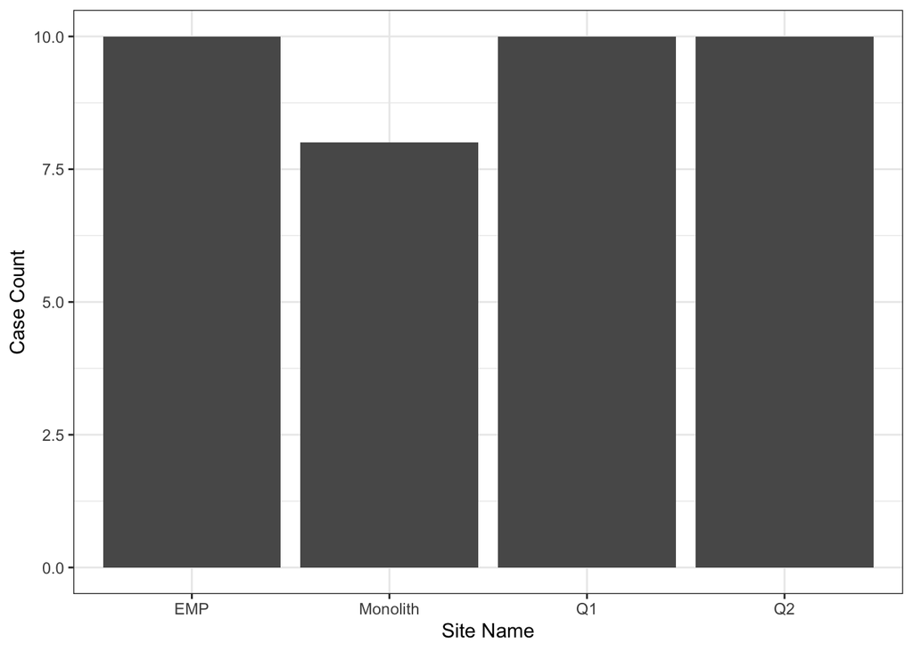

#### Numerical scatterplot

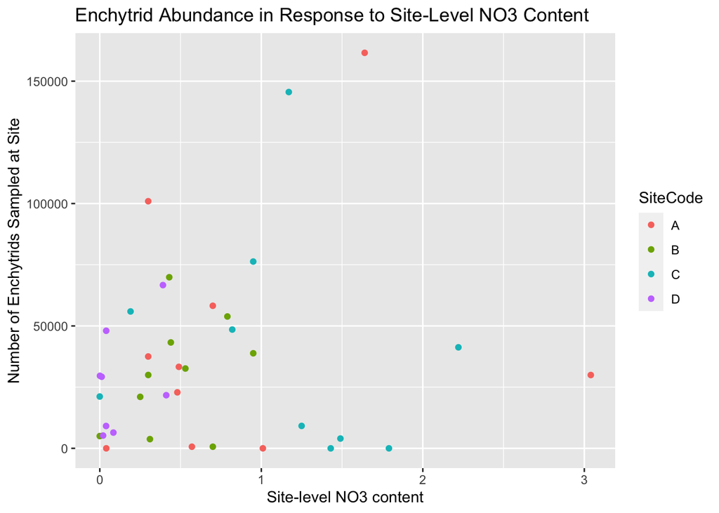

#### R version details

```
               _
platform       x86_64-apple-darwin20
arch           x86_64
os             darwin20
system         x86_64, darwin20
status
major          4
minor          3.1
year           2023
month          06
day            16
svn rev        84548
language       R
version.string R version 4.3.1 (2023-06-16)
nickname       Beagle Scouts
```